# Section 1: Data Loading & Cleaning

### Data Quality Objectives:

1. **Standardize Schema:** Standardize all column names into a consistent `snake_case` format.
2. **Handle Missing Data:** Address missing numerical values through median imputation to avoid distorting distributions.
3. **Consolidate Categorical Levels:** Group missing, blank, or generic placeholder strings (like `"Unknown Device"` or `"Invalid Method"`) into a uniform `"Unknown"` category.
4. **Feature Engineering:** Deriving a contextual `time_of_day` factor variable from the raw transaction timestamps to capture time based fraud patterns.

```r
# Load required libraries
library(dplyr)


# 1. Load the raw dataset
df_raw <- read.csv("fraud_detection_dataset.csv", stringsAsFactors = FALSE)

# 2. Execute pipeline for cleaning and feature engineering
df <- df_raw %>%
  rename_with(tolower) %>%
  rename_with(~ gsub("\\.", "_", .x)) %>%
  mutate(
    # Impute missing transaction amounts with the median
    transaction_amount = ifelse(
      is.na(transaction_amount),
      median(transaction_amount, na.rm = TRUE),
      transaction_amount
    ),
    # Impute missing timestamps with the median hour
    time_of_transaction = ifelse(
      is.na(time_of_transaction),
      median(time_of_transaction, na.rm = TRUE),
      time_of_transaction
    ),
    # Standardize device categories (handles NA, placeholders, and empty strings)
    device_used = ifelse(
      is.na(device_used) | device_used %in% c("Unknown Device", "N/A", "NA", ""),
      "Unknown",
      device_used
    ),
    # Handle missing locations (fixed to catch empty strings "")
    location = ifelse(
      is.na(location) | location == "",
      "Unknown",
      location
    ),
    # Clean and standardize payment methods (fixed to catch empty strings "")
    payment_method = ifelse(
      is.na(payment_method) | payment_method %in% c("Invalid Method", ""),
      "Unknown",
      payment_method
    )
  )

# 3. Feature Engineering: Create time_of_day categorical factor
df <- df %>%
  mutate(time_of_day = case_when(
    time_of_transaction >= 6  & time_of_transaction <= 11 ~ "Morning",
    time_of_transaction >= 12 & time_of_transaction <= 17 ~ "Afternoon",
    time_of_transaction >= 18 & time_of_transaction <= 23 ~ "Evening",
    TRUE                                                  ~ "Night"
  ))

# Convert to ordered factor for logical chronological plotting
df$time_of_day <- factor(df$time_of_day,
                         levels = c("Night", "Morning", "Afternoon", "Evening"))

# Ensure target variable is numeric
df$fraudulent <- as.numeric(df$fraudulent)

# Save the cleaned dataset for modeling phases
write.csv(df, "Fraud_Detection_Dataset_Cleaned.csv", row.names = FALSE)
```

# Section 2: Descriptive Statistics

Before transitioning into advanced predictive modeling, it is essential to establish baseline data distributions and evaluate relationships among variables. Descriptive summaries allow us to evaluate transactional behavior across multiple categorical and continuous dimensions.

### Data Aggregation and Stratification Plan:

1. **Continuous Feature Summaries:** Generate structural summaries of transactional amounts, chronological timestamps, accounts profiles, and velocity constraints.
2. **Target Class Stratification:** Calculate detailed metric comparisons for amount variables across both fraudulent and legitimate categories.
3. **Categorical Proportional Testing:** Construct cross-tabulated contingency profiles evaluating risk ratios across hardware devices and transactional timelines.

```r
# Load summary packages
library(dplyr)
library(tidyr)
library(psych)

# 1. Subset and summarize numerical variables
numeric_vars <- df %>%
  select(transaction_amount, time_of_transaction, previous_fraudulent_transactions,
         account_age, number_of_transactions_last_24h, fraudulent)

describe(numeric_vars)
```

```
##                                  vars     n    mean      sd median trimmed
## transaction_amount                  1 51000 2972.92 4918.80 2524.1 2524.63
## time_of_transaction                 2 51000   11.51    6.75   12.0   11.52
## previous_fraudulent_transactions    3 51000    2.00    1.42    2.0    1.99
## account_age                         4 51000   60.03   34.38   60.0   60.06
## number_of_transactions_last_24h     5 51000    7.50    4.02    7.0    7.49
## fraudulent                          6 51000    0.05    0.22    0.0    0.00
##                                      mad  min     max    range  skew kurtosis
## transaction_amount               1771.25 5.03 49997.8 49992.77  8.68    80.23
## time_of_transaction                 8.90 0.00    23.0    23.00 -0.02    -1.11
## previous_fraudulent_transactions    1.48 0.00     4.0     4.00  0.00    -1.30
## account_age                        44.48 1.00   119.0   118.00  0.00    -1.20
## number_of_transactions_last_24h     4.45 1.00    14.0    13.00  0.01    -1.21
## fraudulent                          0.00 0.00     1.0     1.00  4.17    15.37
##                                     se
## transaction_amount               21.78
## time_of_transaction               0.03
## previous_fraudulent_transactions  0.01
## account_age                       0.15
## number_of_transactions_last_24h   0.02
## fraudulent                        0.00
```

```r
# 2. Stratify financial values by transaction class
df %>%
  group_by(fraudulent) %>%
  summarise(
    n           = n(),
    mean_amt    = round(mean(transaction_amount), 2),
    median_amt  = round(median(transaction_amount), 2),
    sd_amt      = round(sd(transaction_amount), 2),
    min_amt     = round(min(transaction_amount), 2),
    max_amt     = round(max(transaction_amount), 2)
  )
```

```
## # A tibble: 2 × 7
##   fraudulent     n mean_amt median_amt sd_amt min_amt max_amt
##        <dbl> <int>    <dbl>      <dbl>  <dbl>   <dbl>   <dbl>
## 1          0 48490    2967.      2524.  4886.    5.03  49998.
## 2          1  2510    3089.      2524.  5514.   14.3   49998.
```

```r
# 3. Categorical cross-tabulation: Device types vs. Fraud status
df %>%
  group_by(device_used, fraudulent) %>%
  summarise(n = n(), .groups = "drop") %>%
  pivot_wider(names_from = fraudulent, values_from = n, values_fill = 0) %>%
  rename(Not_Fraudulent = `0`, Fraudulent = `1`) %>%
  mutate(fraud_rate = round(Fraudulent / (Not_Fraudulent + Fraudulent) * 100, 2))
```

```
## # A tibble: 4 × 4
##   device_used Not_Fraudulent Fraudulent fraud_rate
##   <chr>                <int>      <int>      <dbl>
## 1 Desktop              15047        748       4.74
## 2 Mobile               14808        806       5.16
## 3 Tablet               14859        729       4.68
## 4 Unknown               3776        227       5.67
```

```r
# 4. Categorical cross-tabulation: Time of day vs. Fraud status
df %>%
  group_by(time_of_day, fraudulent) %>%
  summarise(n = n(), .groups = "drop") %>%
  pivot_wider(names_from = fraudulent, values_from = n, values_fill = 0) %>%
  rename(Not_Fraudulent = `0`, Fraudulent = `1`) %>%
  mutate(fraud_rate = round(Fraudulent / (Not_Fraudulent + Fraudulent) * 100, 2))
```

```
## # A tibble: 4 × 4
##   time_of_day Not_Fraudulent Fraudulent fraud_rate
##   <fct>                <int>      <int>      <dbl>
## 1 Night                11635        579       4.74
## 2 Morning              11379        575       4.81
## 3 Afternoon            14029        733       4.97
## 4 Evening              11447        623       5.16
```

# Section 3: Data Visualization & Research Hypotheses

Visual analytical approaches clarify structural differences across target features. We use density plots, distributions, log scales, and fit-line overlays to systematically explore five strategic research questions regarding operational vulnerabilities.

### Research Questions Explored:

- **Exploratory Base Dist:** Review overall continuous values split by legitimate vs. anomalous target classes.
- **Research Question 1:** Evaluate variance shifts in total calculated fraud rates between unique interaction devices.
- **Research Question 2:** Map conditional probability variations of transaction risk throughout daily windows.
- **Research Question 3:** Analyze whether short-term activity velocity acts as an effective hazard predictor.
- **Research Question 4:** Contrast account maturity duration vectors against overall breach vulnerabilities.
- **Research Question 5:** Track transaction sizing dynamics to identify specific high-value spending patterns.

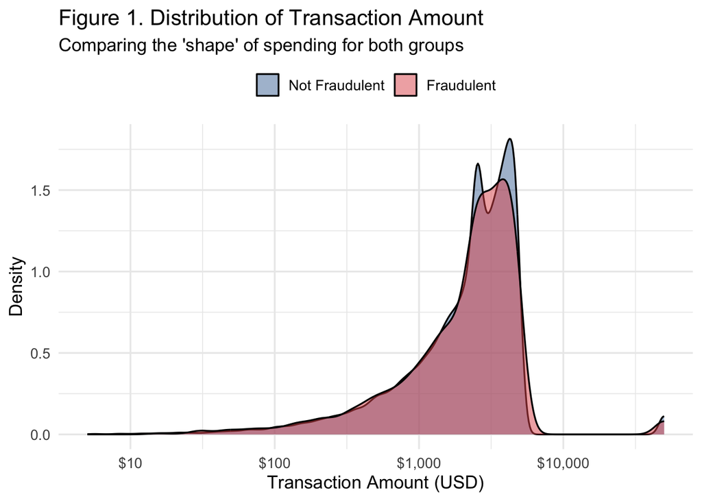

```r
library(ggplot2)
library(scales)

# Set global color profiles for uniform visual storytelling
fraud_colors <- c("0" = "#4E79A7", "1" = "#E15759")

# Figure 1: Transaction Amount Density Profile
p_hist1 <- ggplot(df, aes(x = transaction_amount, fill = factor(fraudulent))) +
  geom_density(alpha = 0.5) +
  scale_fill_manual(values = fraud_colors, labels = c("Not Fraudulent", "Fraudulent")) +
  scale_x_log10(labels = dollar_format()) +
  labs(title = "Figure 1. Distribution of Transaction Amount",
       subtitle = "Comparing the 'shape' of spending for both groups",
       x = "Transaction Amount (USD)", y = "Density", fill = NULL) +
  theme_minimal(base_size = 13) +
  theme(legend.position = "top")
print(p_hist1)
```

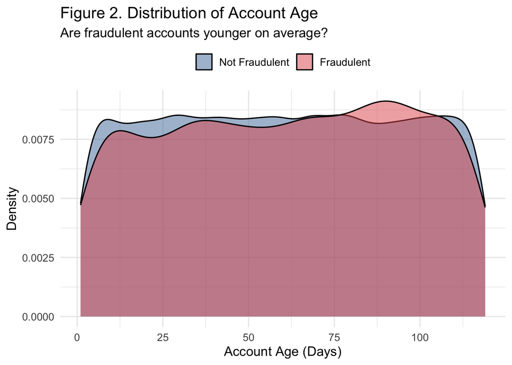

```r
# Figure 2: Account Age Density Profile
p_hist2 <- ggplot(df, aes(x = account_age, fill = factor(fraudulent))) +
  geom_density(alpha = 0.5) +
  scale_fill_manual(values = fraud_colors, labels = c("Not Fraudulent", "Fraudulent")) +
  labs(title = "Figure 2. Distribution of Account Age",
       subtitle = "Are fraudulent accounts younger on average?",
       x = "Account Age (Days)", y = "Density", fill = NULL) +
  theme_minimal(base_size = 13) +
  theme(legend.position = "top")
print(p_hist2)
```

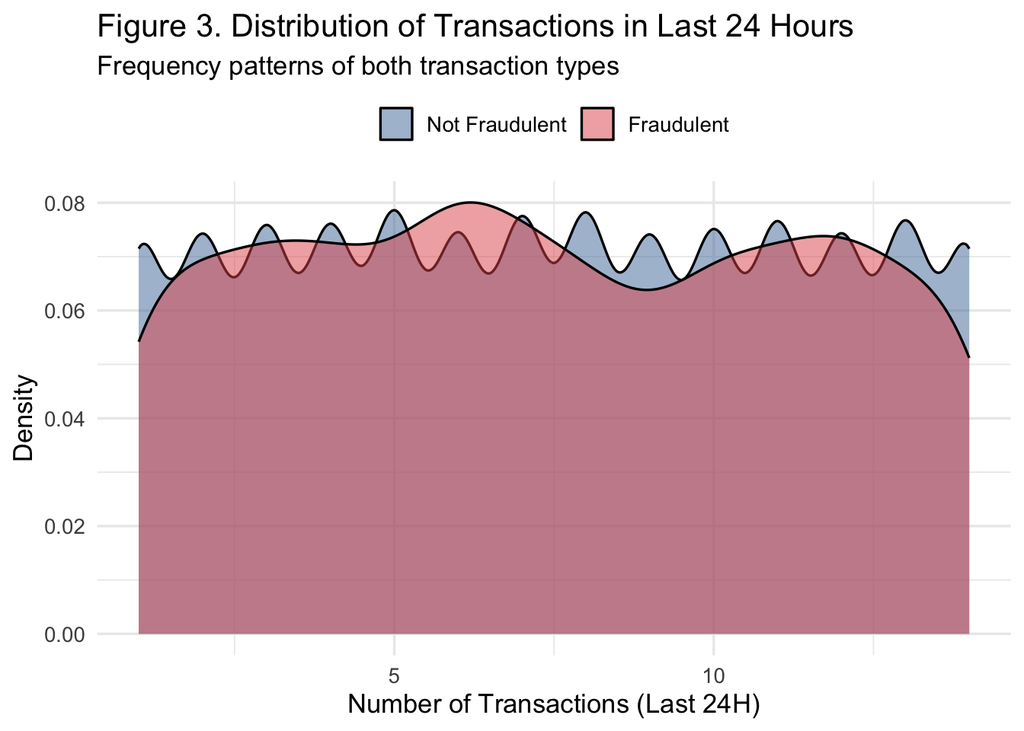

```r
# Figure 3: Short-term Velocity Density Profile
p_hist3 <- ggplot(df, aes(x = number_of_transactions_last_24h, fill = factor(fraudulent))) +
  geom_density(alpha = 0.5) +
  scale_fill_manual(values = fraud_colors, labels = c("Not Fraudulent", "Fraudulent")) +
  labs(title = "Figure 3. Distribution of Transactions in Last 24 Hours",
       subtitle = "Frequency patterns of both transaction types",
       x = "Number of Transactions (Last 24H)", y = "Density", fill = NULL) +
  theme_minimal(base_size = 13) +
  theme(legend.position = "top")
print(p_hist3)
```

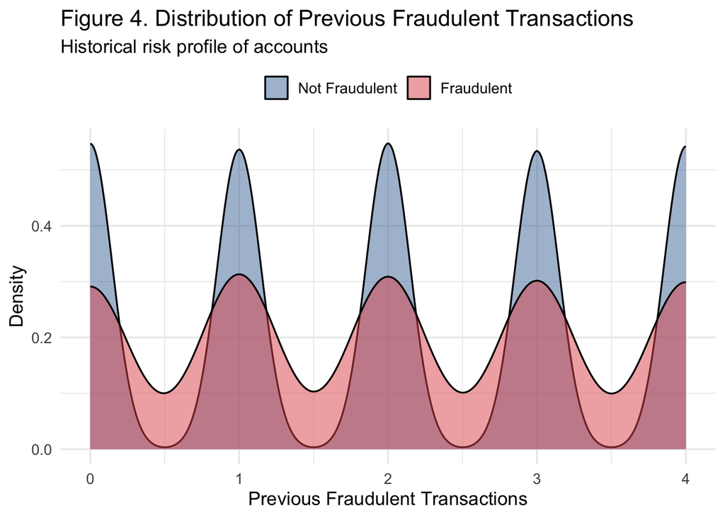

```r
# Figure 4: Historical Infraction Distribution Density
p_hist4 <- ggplot(df, aes(x = previous_fraudulent_transactions, fill = factor(fraudulent))) +
  geom_density(alpha = 0.5) +
  scale_fill_manual(values = fraud_colors, labels = c("Not Fraudulent", "Fraudulent")) +
  labs(title = "Figure 4. Distribution of Previous Fraudulent Transactions",
       subtitle = "Historical risk profile of accounts",
       x = "Previous Fraudulent Transactions", y = "Density", fill = NULL) +
  theme_minimal(base_size = 13) +
  theme(legend.position = "top")
print(p_hist4)
```

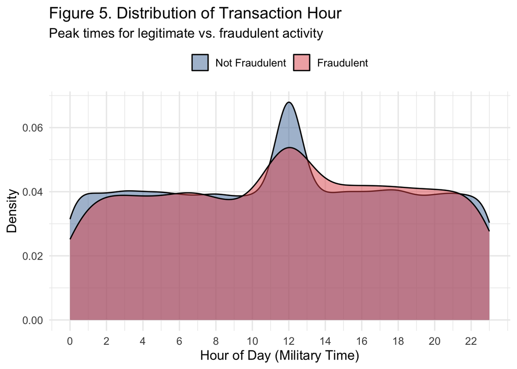

```r
# Figure 5: Hourly Operational Window Timeline
p_hist5 <- ggplot(df, aes(x = time_of_transaction, fill = factor(fraudulent))) +
  geom_density(alpha = 0.5) +
  scale_fill_manual(values = fraud_colors, labels = c("Not Fraudulent", "Fraudulent")) +
  scale_x_continuous(breaks = seq(0, 23, 2)) +
  labs(title = "Figure 5. Distribution of Transaction Hour",
       subtitle = "Peak times for legitimate vs. fraudulent activity",
       x = "Hour of Day (Military Time)", y = "Density", fill = NULL) +
  theme_minimal(base_size = 13) +
  theme(legend.position = "top")
print(p_hist5)
```

### Research Question 1: Which device type has the highest percentage of fraud?

We evaluate the operational breakdown across consumer devices to uncover device-specific risk concentrations within regional locations.

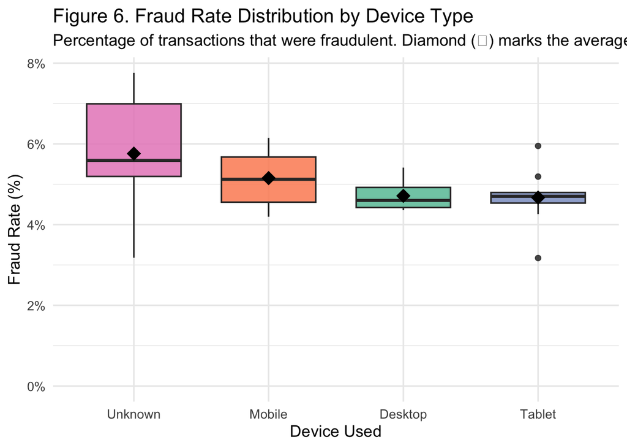

```r
# Boxplot visualization of fraud probabilities calculated by hardware interface
df %>%
  group_by(device_used, location) %>%
  summarise(fraud_rate = (sum(fraudulent) / n()) * 100, .groups = "drop") %>%
  ggplot(aes(x = reorder(device_used, -fraud_rate, FUN = mean),
             y = fraud_rate,
             fill = device_used)) +
  geom_boxplot(alpha = 0.85, width = 0.7) +
  stat_summary(fun = mean, geom = "point", shape = 18, size = 5, color = "black") +
  scale_fill_brewer(palette = "Set2") +
  scale_y_continuous(labels = percent_format(scale = 1), limits = c(0, NA)) +
  labs(title = "Figure 6. Fraud Rate Distribution by Device Type",
       subtitle = "Percentage of transactions that were fraudulent. Diamond (◆) marks the average.",
       x = "Device Used", y = "Fraud Rate (%)", fill = "Device") +
  theme_minimal(base_size = 13) +
  theme(legend.position = "none")
```

### Research Question 2: What is the average probability (risk) of fraud for each time of day?

Evaluating diurnal anomalies allows us to target system monitoring efforts toward high-risk windows throughout the day.

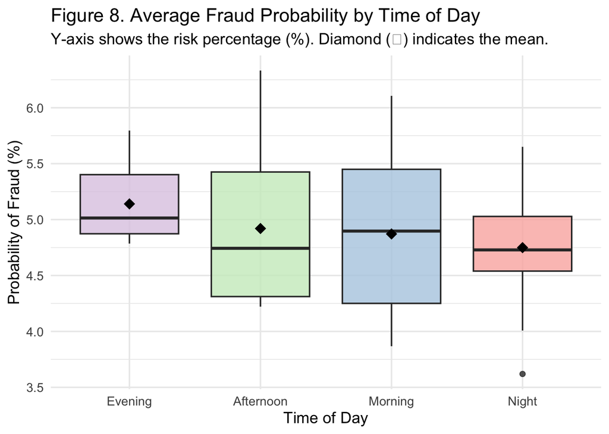

```r
# 1. Quantify hourly fraud probability grouped across geographical bounds
rq2_risk_dist <- df %>%
  group_by(time_of_day, location) %>%
  summarise(
    fraud_rate_pct = (sum(fraudulent) / n()) * 100,
    .groups = "drop"
  )

# 2. Render boxplot output distributions across shifts
p_rq2_boxplot <- ggplot(rq2_risk_dist,
                        aes(x = reorder(time_of_day, -fraud_rate_pct, FUN = mean),
                            y = fraud_rate_pct,
                            fill = time_of_day)) +
  geom_boxplot(alpha = 0.8) +
  stat_summary(fun = mean, geom = "point", shape = 18, size = 4, color = "black") +
  scale_fill_brewer(palette = "Pastel1") +
  labs(title = "Figure 8. Average Fraud Probability by Time of Day",
       subtitle = "Y-axis shows the risk percentage (%). Diamond (◆) indicates the mean.",
       x = "Time of Day", y = "Probability of Fraud (%)", fill = NULL) +
  theme_minimal(base_size = 13) +
  theme(legend.position = "none")

print(p_rq2_boxplot)
```

```r
# 3. Print quantitative reference distributions
rq2_risk_dist %>%
  group_by(time_of_day) %>%
  summarise(
    avg_probability = round(mean(fraud_rate_pct), 2),
    min_prob = round(min(fraud_rate_pct), 2),
    max_prob = round(max(fraud_rate_pct), 2),
    .groups = "drop"
  ) %>%
  arrange(desc(avg_probability))
```

```
## # A tibble: 4 × 4
##   time_of_day avg_probability min_prob max_prob
##   <fct>                 <dbl>    <dbl>    <dbl>
## 1 Evening                5.14     4.79     5.8
## 2 Afternoon              4.92     4.22     6.33
## 3 Morning                4.87     3.87     6.11
## 4 Night                  4.75     3.62     5.65
```

### Research Question 3: Does the number of transactions in the last 24 hours predict whether a transaction is fraudulent?

We apply single-predictor generalized linear structures to evaluate the risk signals from short-term rapid activity.

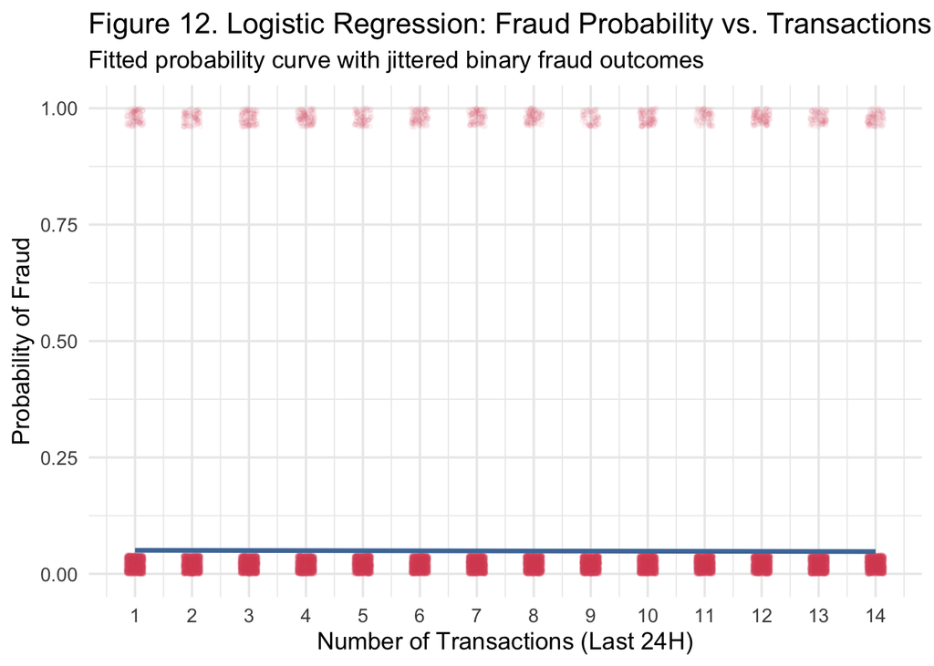

```r
# Jitter scatter plot with embedded binomial curve overlay
p_rq3c <- ggplot(df, aes(x = number_of_transactions_last_24h, y = fraudulent)) +
  geom_jitter(height = 0.04, width = 0.15, alpha = 0.04, size = 0.8, color = "#E15759") +
  geom_smooth(method = "glm", method.args = list(family = "binomial"),
    color = "#4E79A7", linewidth = 1.2, se = TRUE) +
  scale_x_continuous(breaks = seq(floor(min(df$number_of_transactions_last_24h, na.rm = TRUE)),
                                  ceiling(max(df$number_of_transactions_last_24h, na.rm = TRUE)), by = 1)) +
  scale_y_continuous(limits = c(0, 1), breaks = c(0, 0.25, 0.5, 0.75, 1)) +
  labs(title = "Figure 12. Logistic Regression: Fraud Probability vs. Transactions (24H)",
       subtitle = "Fitted probability curve with jittered binary fraud outcomes",
       x = "Number of Transactions (Last 24H)", y = "Probability of Fraud") +
  theme_minimal(base_size = 13)

print(p_rq3c)
```

```r
# Descriptive baseline statistics
df %>%
  group_by(fraudulent) %>%
  summarise(
    n    = n(),
    mean = round(mean(number_of_transactions_last_24h), 2),
    sd   = round(sd(number_of_transactions_last_24h), 2),
    med  = median(number_of_transactions_last_24h),
    .groups = "drop"
  )
```

```
## # A tibble: 2 × 5
##   fraudulent     n  mean    sd   med
##        <dbl> <int> <dbl> <dbl> <dbl>
## 1          0 48490  7.5   4.02     7
## 2          1  2510  7.43  4        7
```

```r
# Calculate model summary outputs
model_rq3 <- glm(fraudulent ~ number_of_transactions_last_24h, data = df, family = binomial)
summary(model_rq3)
```

```
##
## Call:
## glm(formula = fraudulent ~ number_of_transactions_last_24h, family = binomial,
##     data = df)
##
## Coefficients:
##                                  Estimate Std. Error z value Pr(>|z|)
## (Intercept)                     -2.927802   0.043022 -68.054   <2e-16 ***
## number_of_transactions_last_24h -0.004458   0.005092  -0.875    0.381
## ---
## Signif. codes:  0 '***' 0.001 '**' 0.01 '*' 0.05 '.' 0.1 ' ' 1
##
## (Dispersion parameter for binomial family taken to be 1)
##
##     Null deviance: 20012  on 50999  degrees of freedom
## Residual deviance: 20012  on 50998  degrees of freedom
## AIC: 20016
##
## Number of Fisher Scoring iterations: 5
```